# Sleepy mammals and bootstrapping

Derien W

M5 ICA3

# Introduction

Data frame `msleep` is a dataset available in `ggplot2`. It contains information on 83 mammals with regards to their sleep behavior. To get started, load packages `tidyverse` and `infer`.

Below is a basic custom theme. Feel free to try it out when you use `ggplot()`. Simply add it as a layer to your plot. Rather than using `theme_bw()` you can use `theme_custom()`. This custom theme increases the font point size on axes and their labels.

```r
theme_custom <- function() {
  theme_bw() +
  theme(axis.title = element_text(size = 16),
        title = element_text(size = 20),
        axis.text.x = element_text(size = 12),
        axis.text.y = element_text(size = 12),
        plot.caption = element_text(size = 10))
}
```

Take a `glimpse()` at the data below

```r
attach(msleep)
glimpse(msleep)
```

```
Rows: 83
Columns: 11
$ name         <chr> "Cheetah", "Owl monkey", "Mountain beaver", "Greater shor…
$ genus        <chr> "Acinonyx", "Aotus", "Aplodontia", "Blarina", "Bos", "Bra…
$ vore         <chr> "carni", "omni", "herbi", "omni", "herbi", "herbi", "carn…
$ order        <chr> "Carnivora", "Primates", "Rodentia", "Soricomorpha", "Art…
$ conservation <chr> "lc", NA, "nt", "lc", "domesticated", NA, "vu", NA, "dome…
$ sleep_total  <dbl> 12.1, 17.0, 14.4, 14.9, 4.0, 14.4, 8.7, 7.0, 10.1, 3.0, 5…
$ sleep_rem    <dbl> NA, 1.8, 2.4, 2.3, 0.7, 2.2, 1.4, NA, 2.9, NA, 0.6, 0.8, …
$ sleep_cycle  <dbl> NA, NA, NA, 0.1333333, 0.6666667, 0.7666667, 0.3833333, N…
$ awake        <dbl> 11.9, 7.0, 9.6, 9.1, 20.0, 9.6, 15.3, 17.0, 13.9, 21.0, 1…
$ brainwt      <dbl> NA, 0.01550, NA, 0.00029, 0.42300, NA, NA, NA, 0.07000, 0…
$ bodywt       <dbl> 50.000, 0.480, 1.350, 0.019, 600.000, 3.850, 20.490, 0.04…
```

For all the questions that follow, use a sequence of functions in package `infer`. For details on `msleep`, type `?msleep` in your console.

# Test of Hypothesis

Past research has shown that humans have a **median** sleep time of 7.5 hours per day. Researchers want to investigate if all other mammals have a higher median number of sleep hours per day. A random sample of 82 mammals revealed a median number of sleep hours per day to be 10.1 hours. Is this enough evidence to suggest mammals that are not human have a higher median number of sleep hours per day?

```r
msleep %>%
  filter(name != "Human") %>%
  specify(response = sleep_total) %>%
  hypothesise(null = "point", med = 7.5) %>%
  generate(reps = 10000, type = "bootstrap") %>%
  calculate(stat = "median")
```

|  | replicate | stat |
| --- | --- | --- |
| 1 | 1 | 7.60 |
| 2 | 2 | 7.75 |
| 3 | 3 | 7.40 |
| 4 | 4 | 7.10 |
| 5 | 5 | 7.60 |
| 6 | 6 | 7.65 |
| 7 | 7 | 7.40 |
| 8 | 8 | 8.35 |
| 9 | 9 | 7.35 |
| 10 | 10 | 7.50 |

[output cut: 9990 more lines]

## Test for the median

### Simulated null distribution

Plot a histogram of the simulated null distribution and place a vertical line at the value of the observed sample median of 10.1.

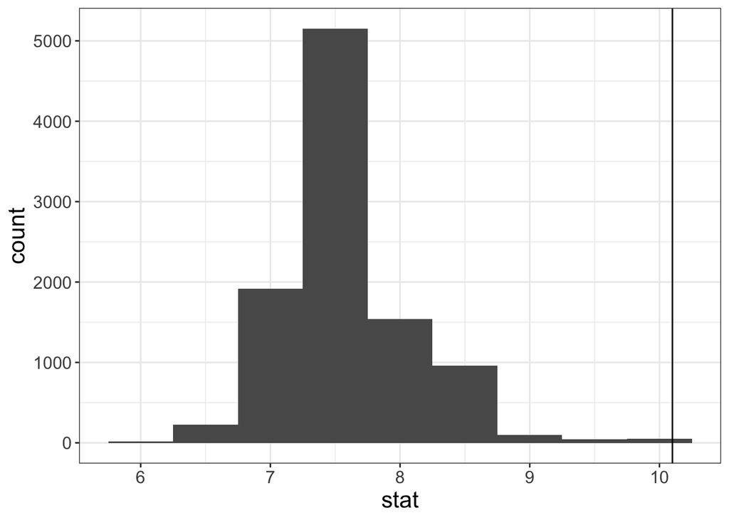

### Compute the p-value

Use the simulated null distribution to compute the p-value. Recall that the p-value is the probability of observing data at least as favorable to the alternative hypothesis as the current data set, given that the null hypothesis is true.

```r
null.dist %>%
  filter(stat >= 10.1) %>%
  summarise(p_value = 2 * n() / nrow(null.dist))
```

| p_value |
| --- |
| 2e-04 |

### Conclusion

State your conclusion in the context of the problem. #The the p-value is less than the alpha, 0.05, so that leads us to reject the null hypothesis ## How about the mean?

We have discussed about the average sleep hours in our class lecture in context of a two sided hypothesis test. Let us examine how it changes (if at all) when the test is one sided.

On average, it is believed that humans need 8 hours of sleep per day. Using the same sample as above, it was found that the average number of sleep hours per day to be 10.4 hours for all other mammals except humans. Is this enough evidence to suggest mammals that are not human have a higher mean number of sleep hours per day?

### Simulated null distribution

Plot a histogram of the simulated null distribution and place a vertical line at the value of the observed sample mean of 10.4.

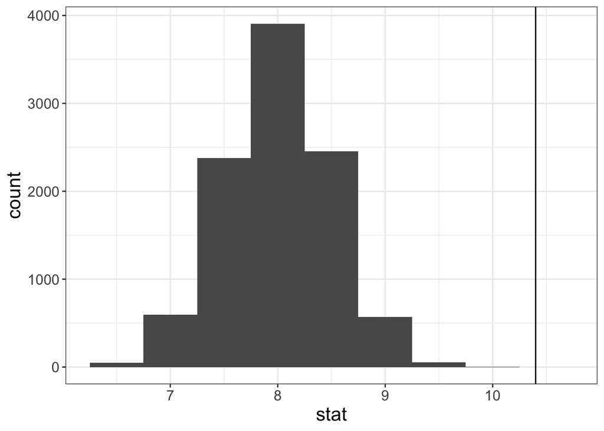

```r
null.dist1 <- msleep %>%
  filter(name != "Human") %>%
  specify(response = sleep_total) %>%
  hypothesise(null = "point", mu = 8) %>%
  generate(reps = 10000, type = "bootstrap") %>%
  calculate(stat = "mean")

ggplot(null.dist1, aes(stat)) + geom_histogram(binwidth = .5) + geom_vline(xintercept = 10.4) + theme_custom()
```

### Compute the p-value

Use the simulated null distribution to compute the p-value. Recall that the p-value is the probability of observing data at least as favorable to the alternative hypothesis as the current data set, given that the null hypothesis is true.

```r
null.dist %>%
  filter(stat >= 10.4) %>%
  summarise(p_value = 1 * n() / nrow(null.dist1))
```

| p_value |
| --- |
| 0 |

### Conclusion

Did the conclusion change when the parameter was changed from median to mean? Justify your answer. #No, the conclusion did not change. We still reject the null hypothesis.

## One sided vs. two sided

If our research question was: is this enough evidence to suggest that mean number of sleep hours per day for mammals that are not human is different from humans, how would our hypothesis test change? #If you’re testing for one thing that’s greater, then it’s one sided, but if testing for more than one thing that’s greater, it’s a two sided test. The hypothesis would change.

## Plausible value of the population parameter?

Based on the given data, had our hypothesized mean been 9.5, would our conlcusion have changed? Perform both the one-sided and two-sided test and state the conclusions.

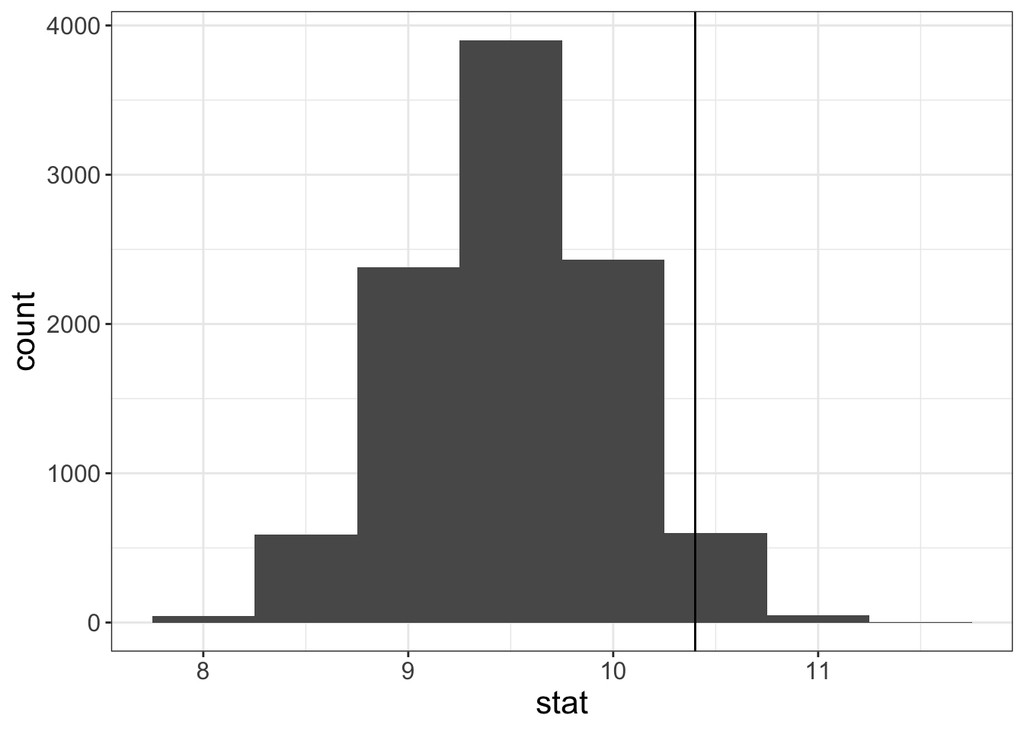

```r
null.dist1 <- msleep %>%
  filter(name != "Human") %>%
  specify(response = sleep_total) %>%
  hypothesise(null = "point", mu = 9.5) %>%
  generate(reps = 10000, type = "bootstrap") %>%
  calculate(stat = "mean")

ggplot(null.dist1, aes(stat)) + geom_histogram(binwidth = .5) + geom_vline(xintercept = 10.4) + theme_custom()
```

```r
## Yes, the conclusion would have changed. The null hypothesis would not be rejected.
```

[output not shown]

[output not shown]